# Лабораторная работа №3

Агентное моделирование.

Разанацуа Сара Естэлл

Российский университет дружбы народов, Москва, Россия

## Цель работы

Агентный подход к имитационному моделированию (Agent-Based Modeling, ABM) — это метод исследования сложных систем, в котором поведение системы возникает из взаимодействия множества автономных сущностей, называемых агентами. Вместо того чтобы описывать систему глобальными уравнениями, мы моделируем каждую индивидуальную единицу и правила её поведения, а затем наблюдаем, какие коллективные паттерны появляются снизу вверх. Этот подход особенно полезен, когда поведение системы трудно предсказать из-за нелинейностей, гетерогенности участников или адаптивных стратегий.

## Задание

1. Создать рабочий каталог для кода.
2. Установить необходимые пакеты.
3. Выполнить предложенный код.
4. Преобразовать код в литературный стиль.
5. Сгенерировать из литературного кода:
- чистый код;
- jupyter notebook;
- документацию в формате Quarto.
6. Выполнить код из jupyter notebook.
7. Интегрировать документацию в формате Quarto в отчёт.
8. Добавить в код в литературном стиле вычисление для набора параметров.
9. Сгенерировать из литературного кода с параметрами:
- чистый код;
- jupyter notebook;
- документацию в формате Quarto.
10. Выполнить код из jupyter notebook с параметрами.
11. Интегрировать документацию с параметрами в формате Quarto в отчёт.
- Результирующие файлы не удаляйте, выложите на git.

## Выполнение лабораторной работы

## Реализация на Agents.jl

- Мы создадим файл src/daisyworld.jl. Здесь мы определим тип агента и функции шага модели.

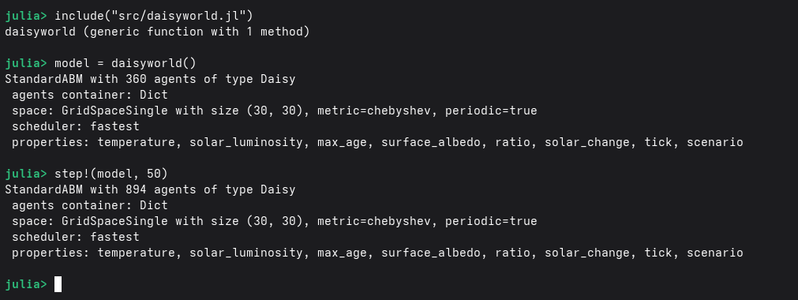

Рис

## Реализация на Agents.jl

- Таблица, которая мы получили.

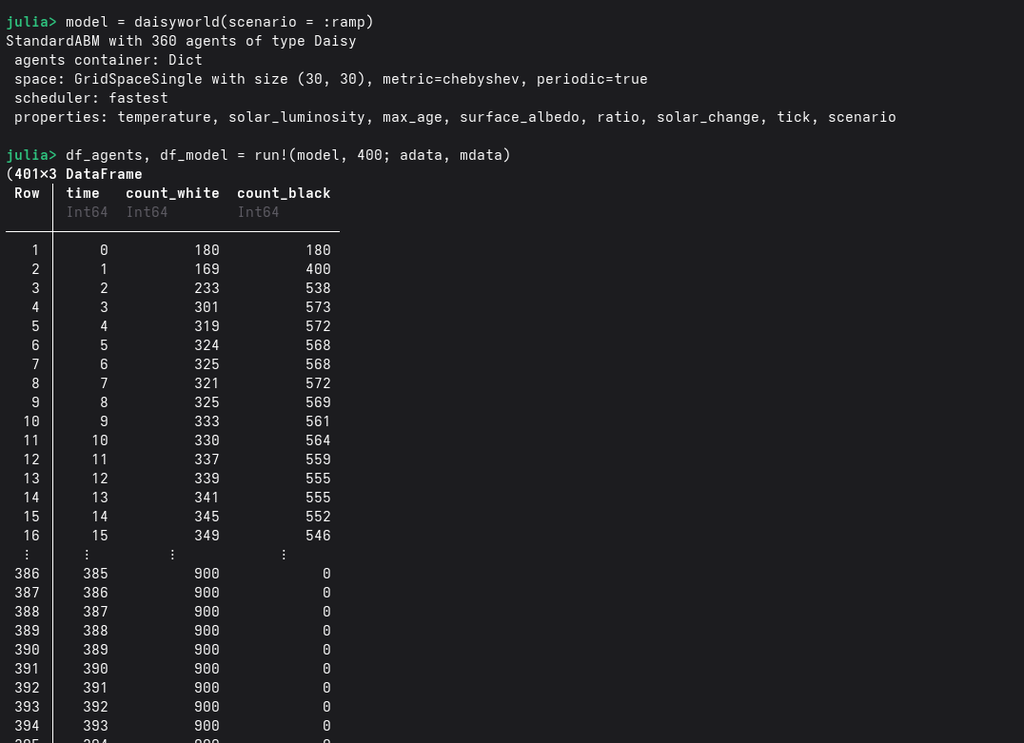

Рис

## Реализация на Agents.jl

- График баланса населении.

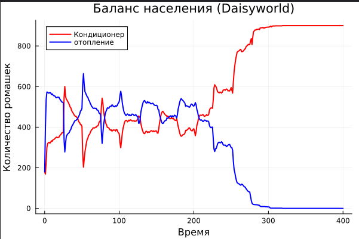

Рис

## Базовая визуализация

- Анализ полученной визуализации показывает неоднородное распределение температуры по поверхности модели. Можно заметить корреляцию между плотностью популяции маргариток и локальной температурой: черные маргаритки (с низким альбедо) способствуют поглощению тепла, в то время как белые маргаритки (с высоким альбедо) отражают солнечное излучение. Данная визуализация является отправной точкой для исследования механизмов саморегуляции климата в модели.

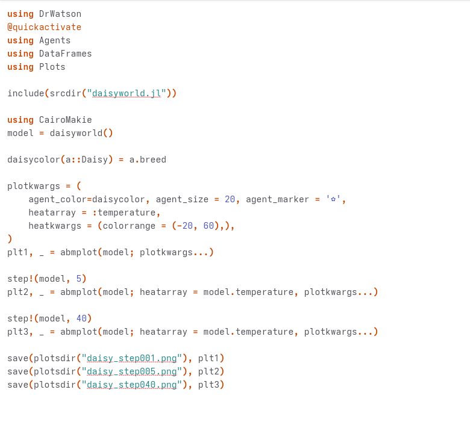

Рис

## Базовая визуализация

- Визуализация 1:

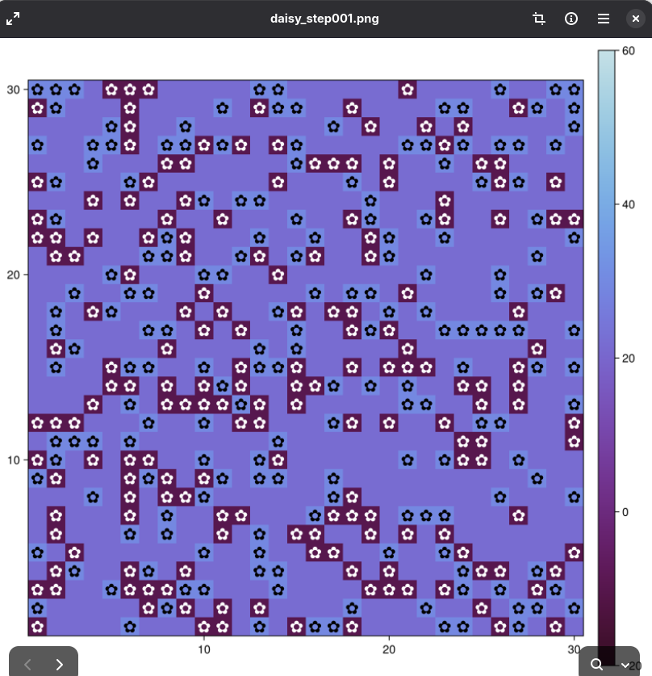

Рис

## Базовая визуализация

- Визуализация 2:

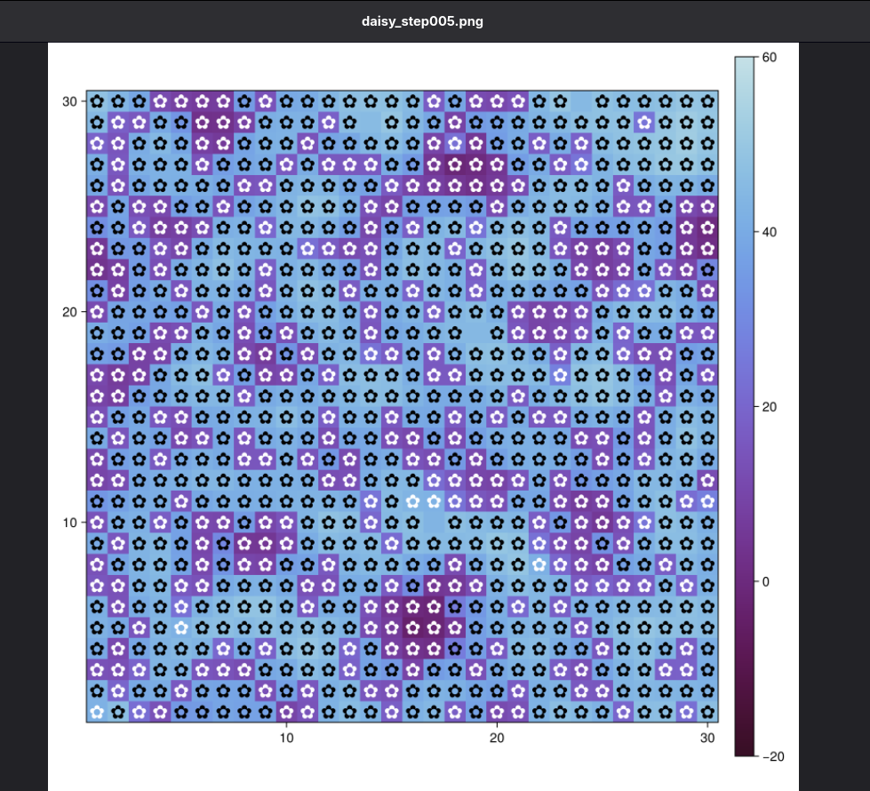

Рис

## Базовая визуализация

- Визуализация 3:

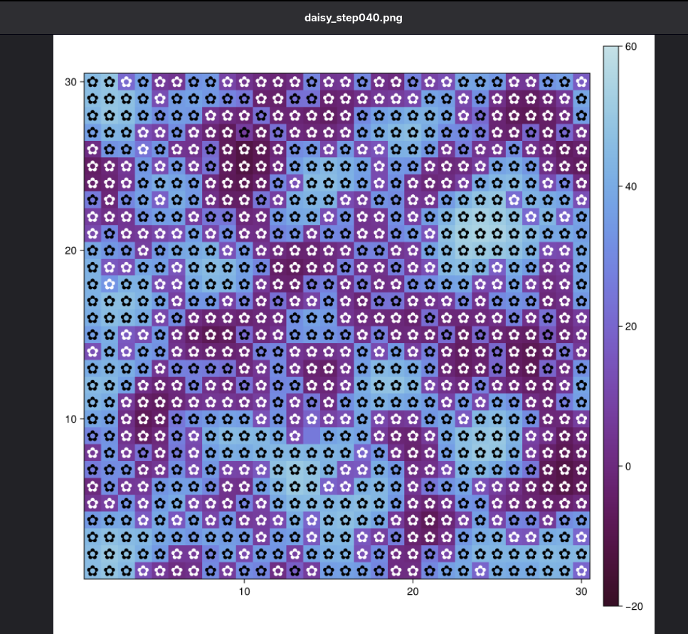

Рис

## Анимация модели

- Создание файла scripts/daisyworld-animate.jl.

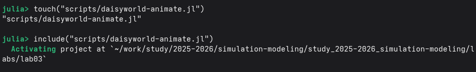

Рис

## Анимация модели

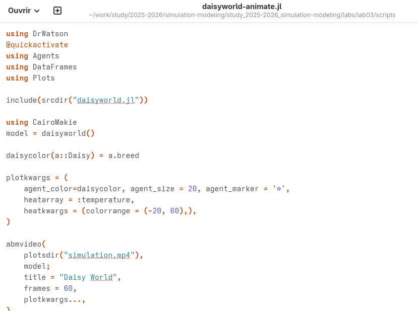

Рис

## Динамика числа маргариток

- Построим график изменения числа маргариток в зависимости от модельного времени

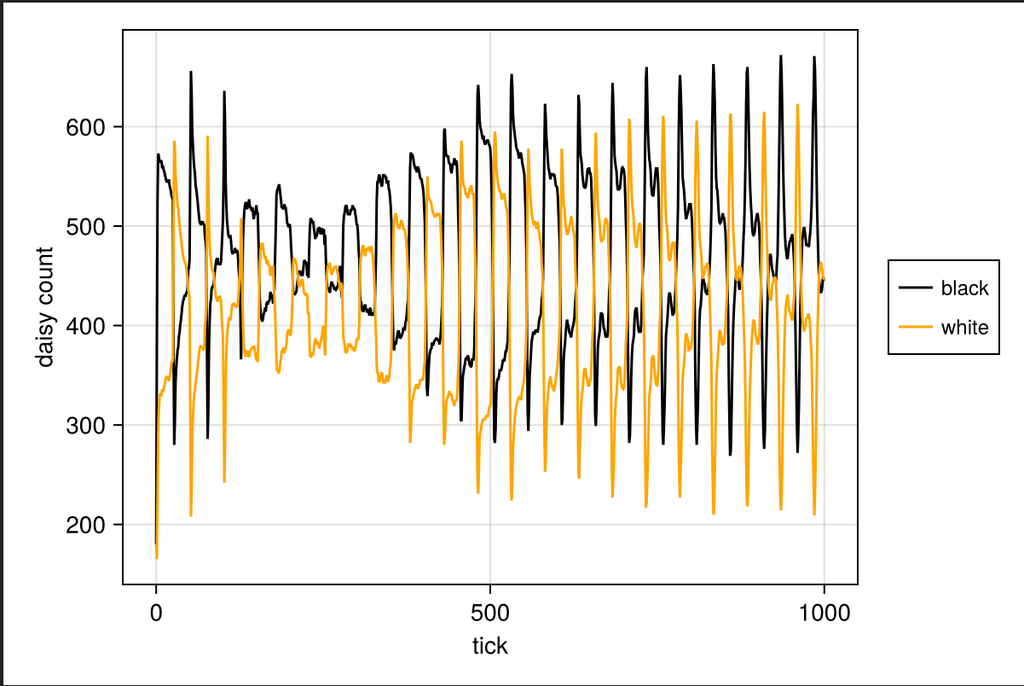

Рис

## Динамика числа маргариток

- Сгенерирование из литературного кода: jupyter notebook

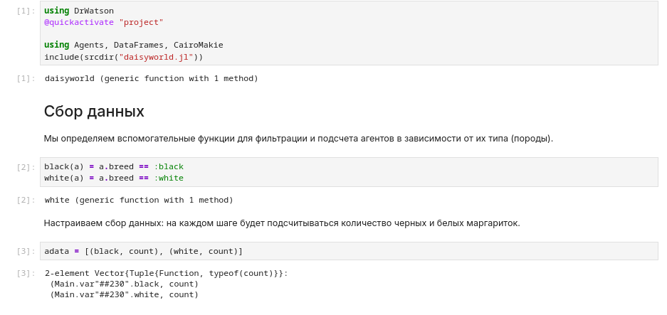

Рис

## Динамика числа маргариток

- Таблица

[figure not shown]

Рис

## Динамика числа маргариток

- Визуализации

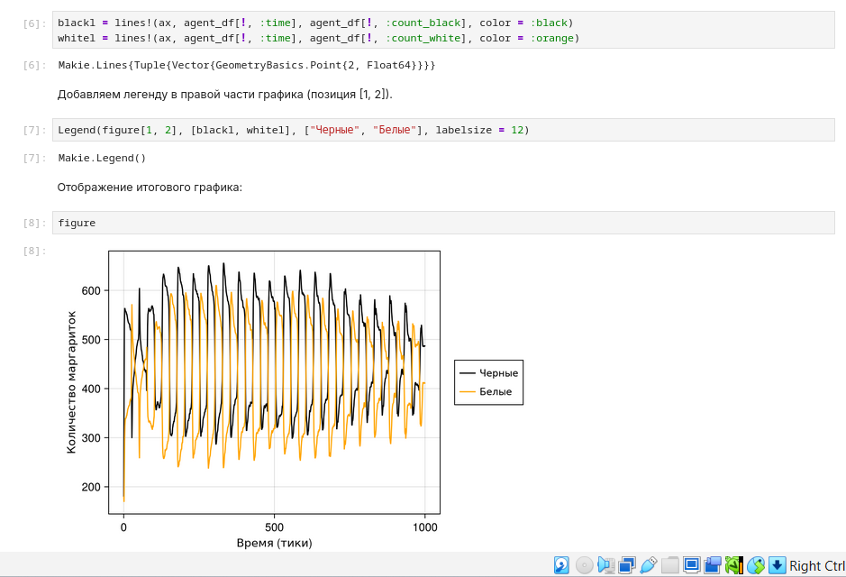

Рис

## Динамика модели

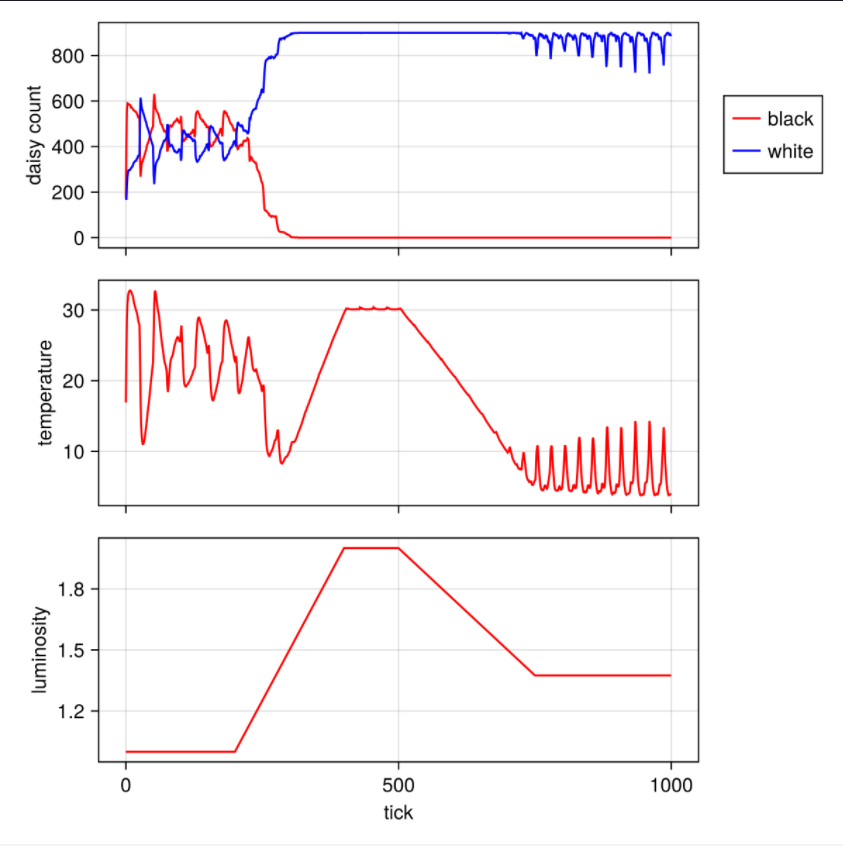

Рис

## Динамика модели

- Визуализации в jupyter notebook

[figure not shown]

Рис

## Базовая визуализация (параметры)

- В данном подразделе реализовано расширение базовой модели за счет введения варьируемых параметров эксперимента. С помощью словаря param_dict определены диапазоны значений для таких характеристик, как максимальный возраст маргариток (max_age) и начальная доля белых маргариток (init_white). Это позволяет автоматизировать процесс проведения серии симуляций (ensemble runs) и в дальнейшем проанализировать, как начальные условия влияют на стабильность климатической системы “Мира маргариток”.

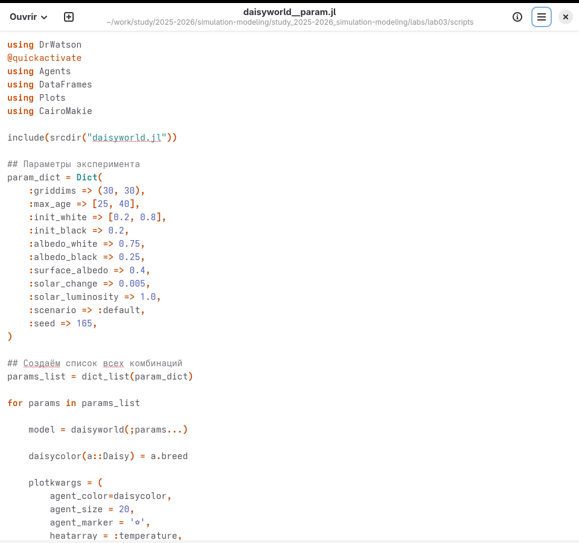

Рис

## Базовая визуализация (параметры)

- Визуализации 1

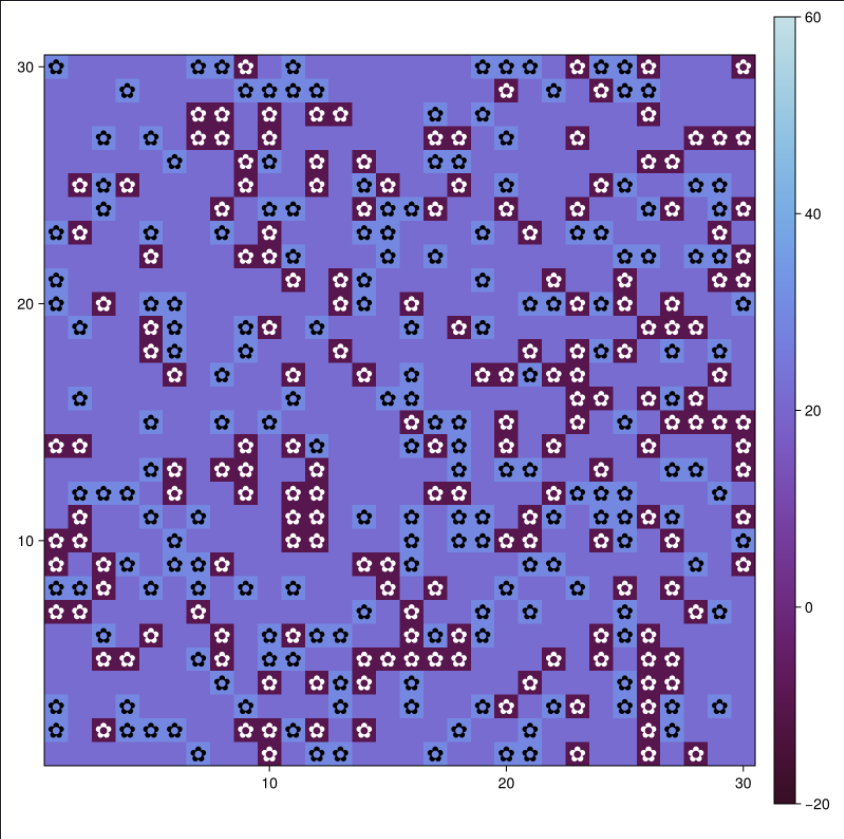

Рис

## Базовая визуализация (параметры)

- Визуализации 2

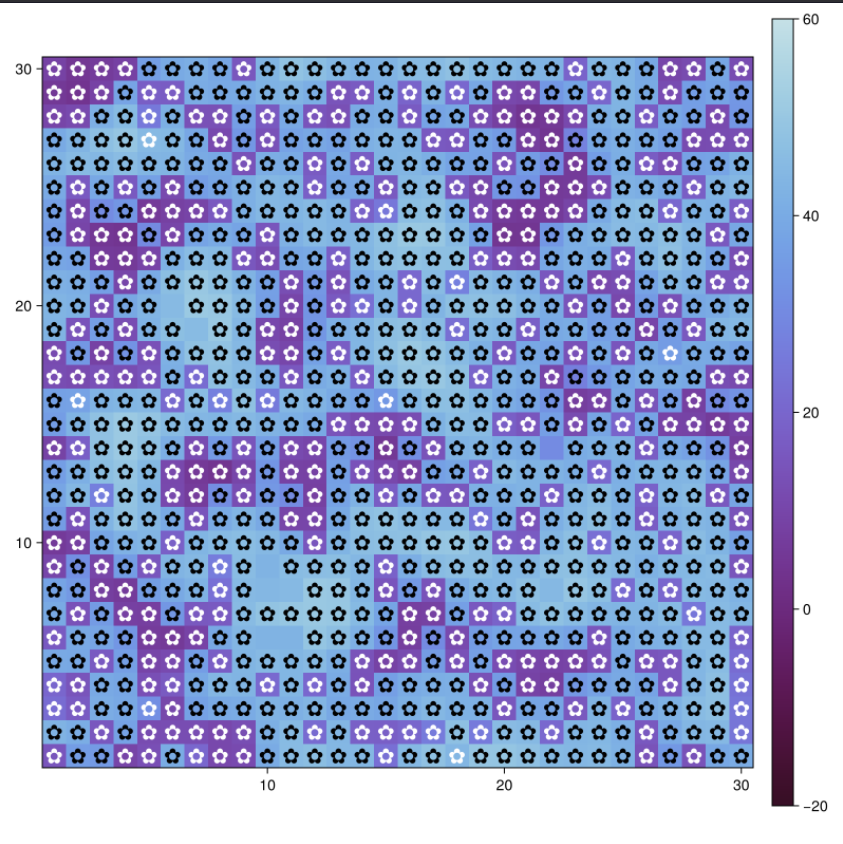

Рис

## Базовая визуализация (параметры)

- Визуализации 3

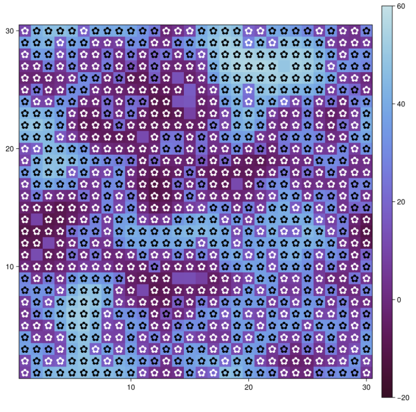

Рисунок

## Динамика числа маргариток (параметры)

- Процесс генерации графиков динамики был полностью автоматизирован в рамках парадигмы литературного программирования. Код из файла scripts/daisyworld-count__param.jl интегрирован в итоговый отчет Quarto, что гарантирует соответствие представленных данных текущим настройкам параметров эксперимента. Такой подход исключает ошибки ручного переноса данных и позволяет быстро пересчитать все результаты при изменении исходных условий в словаре параметров.

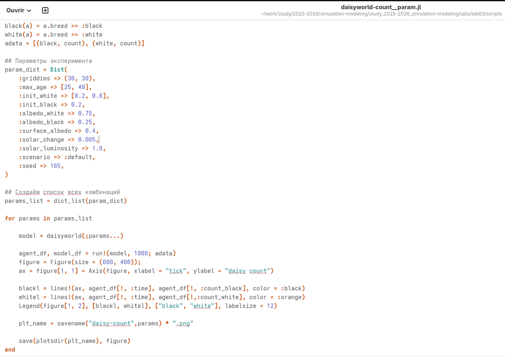

Рис

## Динамика числа маргариток (параметры)

- Визуализации 1

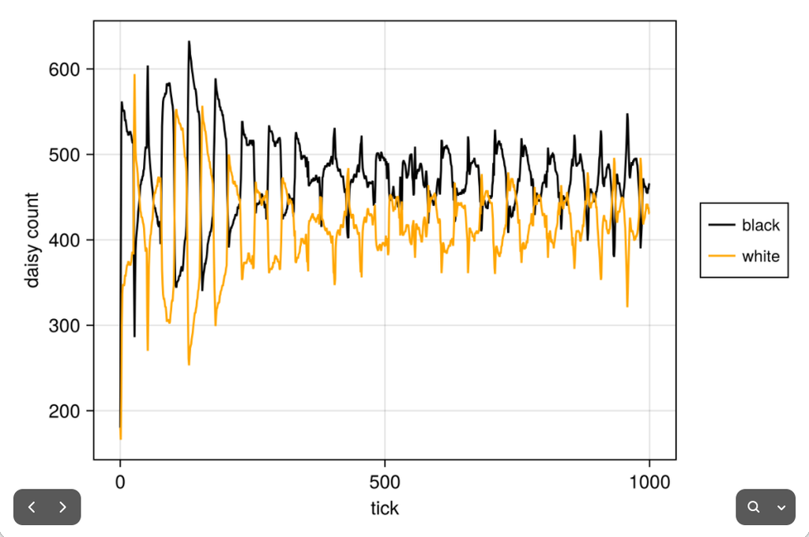

Рис

## Динамика числа маргариток (параметры)

- Визуализации 2

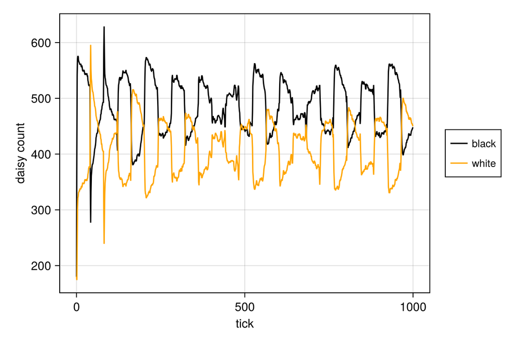

Рис

## Динамика числа маргариток (параметры)

- Визуализации 3

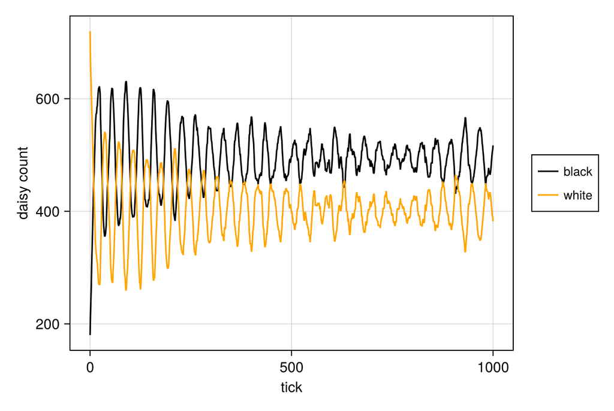

Рис

## Динамика числа маргариток (параметры)

- Визуализации 4

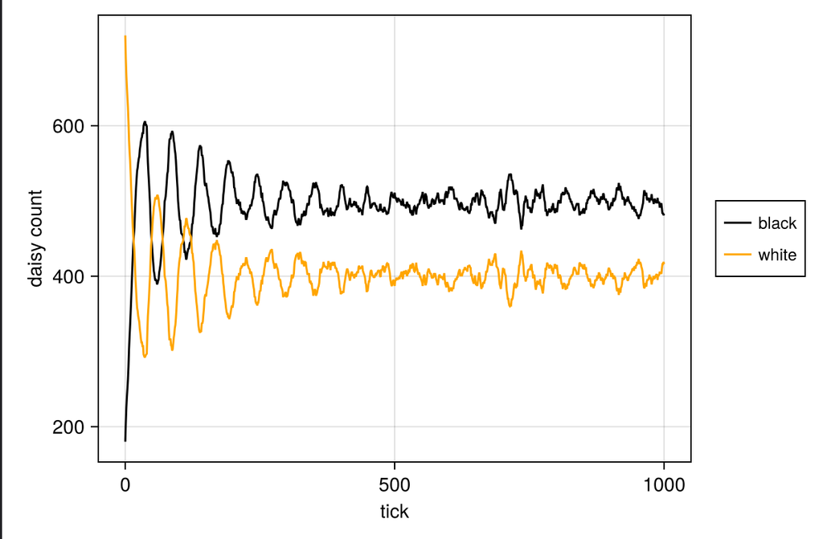

Рис

## Динамика модели (параметры)

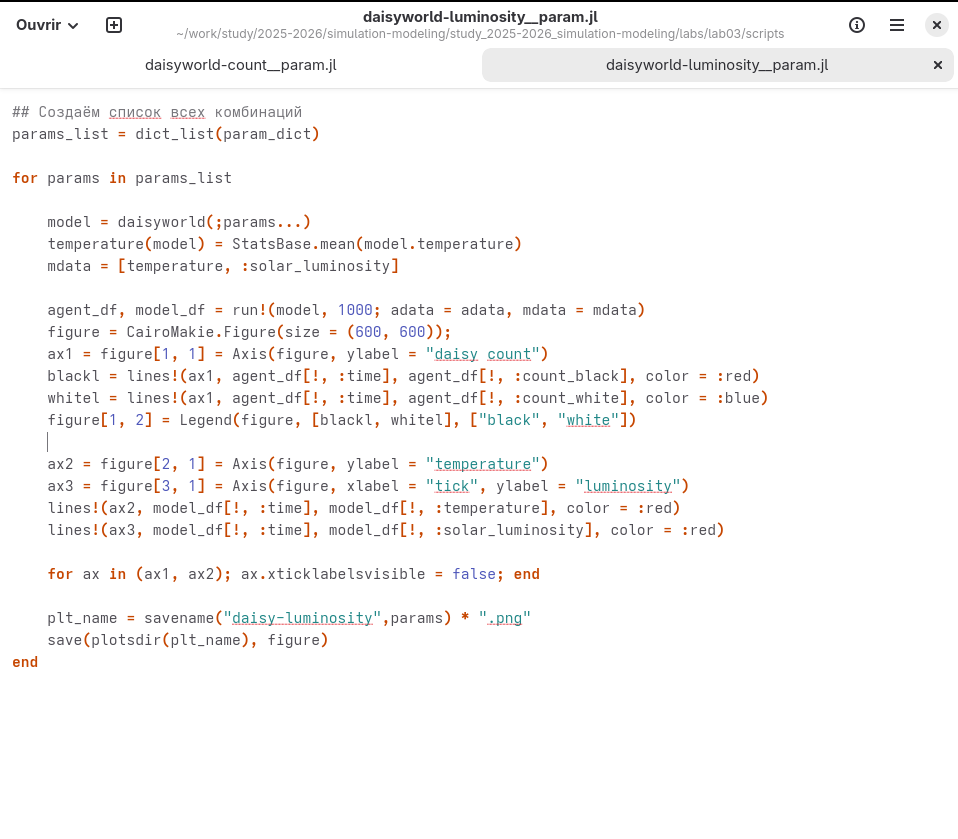

Рис

## Динамика модели (параметры)

- Визуализации 1

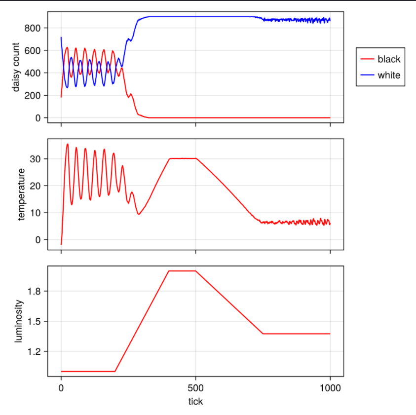

Рис

## Динамика модели (параметры)

- Визуализации 2

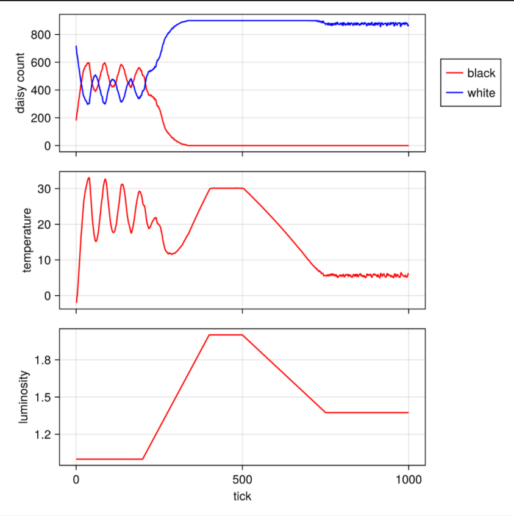

Рис

## Динамика модели (параметры)

- Визуализации 3

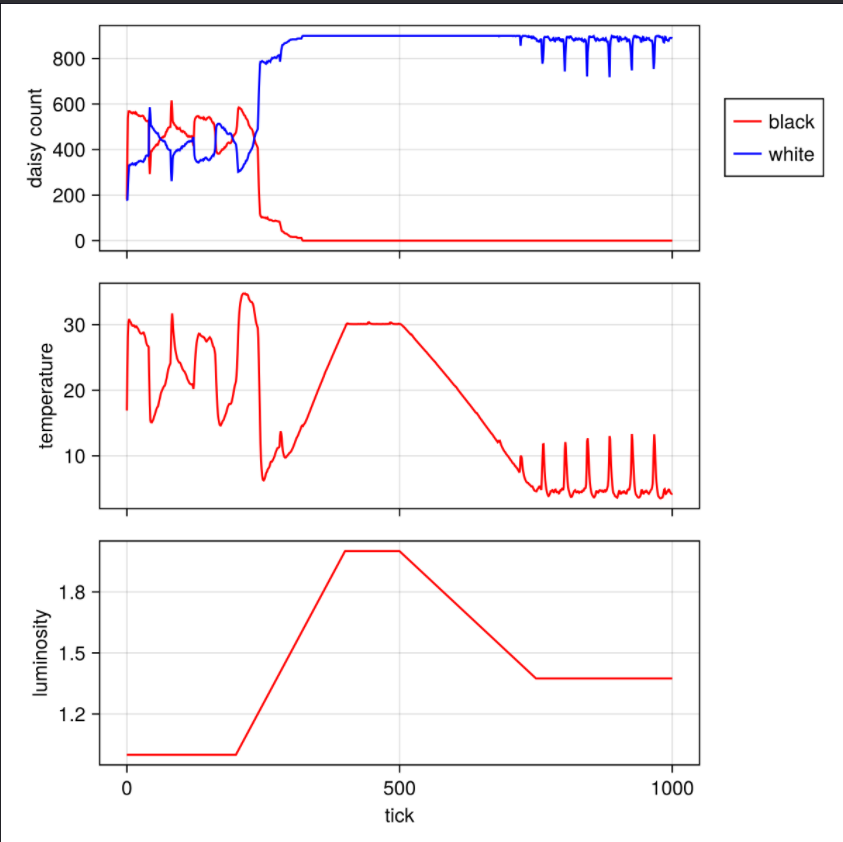

Рис

## Выводы

- Я выполнила лабораторную работу.